# Building Manner Prediction Model of Weight Lifting Exercises

Yap Koon Hoe

December 24, 2015

## Synopsis

In this report we aim to predict the manner applied in weight lifting exercises(WLE). The devices such as Jawbone Up, Nike FuelBand, and Fitbit are part of the quantified self movement tested on a group of enthusiasts who take measurements about themselves regularly to improve their health, to find patters in their behavior, or because they are tech geeks. The measurements are taken from the accelerometers on the belt, forearm, arm, and dumbell of the 6 pariticipants performing the barbell lifts correctly and incrrectly in 5 different ways.

## Data Processing

From the [Human Activity Recognition Research](http://groupware.les.inf.puc-rio.br/har), it has described the WLE dataset which can be downloaded as below:

```
a. [Training data](https://d396qusza40orc.cloudfront.net/predmachlearn/pml-training.csv)
b. [Test data](https://d396qusza40orc.cloudfront.net/predmachlearn/pml-testing.csv)
```

We read in the WLE dataset from the raw text file stored in csv format where fields are delimited with the comma. By examining the dataset, there are some missing values appeared as empty, NA as well as “#DIV/0!”.

```r
wleTrainUrl <- "https://d396qusza40orc.cloudfront.net/predmachlearn/pml-training.csv"
wleTrainFile<- "pml-training.csv"
download.file(wleTrainUrl,destfile=wleTrainFile,method="curl")
wleTrainRaw<-read.csv(wleTrainFile, sep = ",", na.strings = c("","NA","#DIV/0!"))

wleTestUrl <- "https://d396qusza40orc.cloudfront.net/predmachlearn/pml-testing.csv"
wleTestFile<- "pml-testing.csv"
download.file(wleTestUrl,destfile=wleTestFile,method="curl")
wleTestRaw<-read.csv(wleTestFile, sep = ",", na.strings = c("","NA","#DIV/0!"))
```

```r
dim(wleTrainRaw)
```

```
## [1] 19622   160
```

```r
dim(wleTestRaw)
```

```
## [1]  20 160
```

## Data Cleaning

Remove the X, user_name, raw_timestamp_part_1, raw_time_part_2, cvtd_timestamp, new_window and num_window columns.

```r
wleTrainRaw<-wleTrainRaw[,-c(1:7)]
```

```r
wleTrainRaw<-wleTrainRaw[,colSums(is.na(wleTrainRaw))<.7*nrow(wleTrainRaw)]
dim(wleTrainRaw)
```

```
## [1] 19622    53
```

Select the same column names for training set following the testing set These testing set will be used for cross validation.

```r
wleValidate<-wleTestRaw[,c(colnames(wleTrainRaw)[1:52],'problem_id')]
dim(wleValidate)
```

```
## [1] 20 53
```

## Data Slicing

Since the training set is large, it will be divided as 75% observations for training subset and the remaining as test subset. For reproducibility purposes, the seed is setto 1221.

```r
library(caret)
set.seed(1221)
wleTrainDP<-createDataPartition(y=wleTrainRaw$classe, p=0.75, list=FALSE)
wleTrainSS<-wleTrainRaw[wleTrainDP,]
wleTestSS<-wleTrainRaw[-wleTrainDP,]
rbind("Training subset"=dim(wleTrainSS), "Test subset"=dim(wleTestSS))
```

```
##                  [,1] [,2]
## Training subset 14718   53
## Test subset      4904   53
```

## Checking Zero Covariates

There are no zero variance predictors or near-zero variance predictors exist, thus no predictors will be removed in the construction of the prediction model.

```r
nzv<-nearZeroVar(wleTrainSS, saveMetrics=TRUE)
str(nzv, vec.len=2)
```

```
## 'data.frame':    53 obs. of  4 variables:
##  $ freqRatio    : num  1.16 1.01 ...
##  $ percentUnique: num  7.8 11.6 ...
##  $ zeroVar      : logi  FALSE FALSE FALSE ...
##  $ nzv          : logi  FALSE FALSE FALSE ...
```

```r
nzv[nzv[,"zeroVar"]+nzv[,"nzv"]>0,]
```

```
## [1] freqRatio     percentUnique zeroVar       nzv
## <0 rows> (or 0-length row.names)
```

## Building Model With Classification Tree

```r
time1<-proc.time()
ctreeFit<-train(classe~.,method="rpart",data=wleTrainSS)
time2<-proc.time()
ctreeTime<-time2-time1
#the duration used for building the model
ctreeTime
```

```
##    user  system elapsed
##  15.045   0.888  16.150
```

```r
print(ctreeFit$finalModel)
```

```
## n= 14718
##
## node), split, n, loss, yval, (yprob)
##       * denotes terminal node
##
##  1) root 14718 10533 A (0.28 0.19 0.17 0.16 0.18)
##    2) roll_belt< 130.5 13468  9291 A (0.31 0.21 0.19 0.18 0.11)
##      4) pitch_forearm< -34.35 1178     4 A (1 0.0034 0 0 0) *
##      5) pitch_forearm>=-34.35 12290  9287 A (0.24 0.23 0.21 0.2 0.12)
##       10) magnet_dumbbell_y< 439.5 10408  7466 A (0.28 0.18 0.24 0.19 0.11)
##         20) roll_forearm< 123.5 6470  3831 A (0.41 0.18 0.18 0.17 0.06) *
##         21) roll_forearm>=123.5 3938  2625 C (0.077 0.18 0.33 0.23 0.18) *
##       11) magnet_dumbbell_y>=439.5 1882   926 B (0.032 0.51 0.038 0.23 0.19) *
##    3) roll_belt>=130.5 1250     8 E (0.0064 0 0 0 0.99) *
```

[output not shown]

[figure not shown]

```r
rattle::fancyRpartPlot(ctreeFit$finalModel)
```

#Cross-Validation With Classification Tree Model

```r
confusionMatrix(wleTestSS$classe, predict(ctreeFit, wleTestSS))
```

```
## Confusion Matrix and Statistics
##
##           Reference
## Prediction    A    B    C    D    E
##          A 1264   20  105    0    6
##          B  385  330  234    0    0
##          C  405   36  414    0    0
##          D  374  137  293    0    0
##          E  138  124  250    0  389
##
## Overall Statistics
##
##                Accuracy : 0.4888
##                  95% CI : (0.4747, 0.5029)
##     No Information Rate : 0.5232
##     P-Value [Acc > NIR] : 1
##
##                   Kappa : 0.3315
##  Mcnemar's Test P-Value : NA
##
## Statistics by Class:
##
##                      Class: A Class: B Class: C Class: D Class: E
## Sensitivity            0.4926  0.51005  0.31944       NA  0.98481
## Specificity            0.9440  0.85459  0.87777   0.8361  0.88645
## Pos Pred Value         0.9061  0.34773  0.48421       NA  0.43174
## Neg Pred Value         0.6290  0.91985  0.78217       NA  0.99850
## Prevalence             0.5232  0.13193  0.26427   0.0000  0.08055
## Detection Rate         0.2577  0.06729  0.08442   0.0000  0.07932
## Detection Prevalence   0.2845  0.19352  0.17435   0.1639  0.18373
## Balanced Accuracy      0.7183  0.68232  0.59861       NA  0.93563
```

## Building Model With Random Forest

```r
library(randomForest)
time1<-proc.time()
rforestFit<-randomForest(classe~.,data=wleTrainSS, importance=TRUE)
time2<-proc.time()
rforestTime<-time2-time1
#the duration used for building the model
rforestTime
```

```
##    user  system elapsed
## 108.847   0.960 111.956
```

```r
# return the first 6 rows of the second tree
head(getTree(rforestFit,k=2))
```

```
##   left daughter right daughter split var split point status prediction
## 1             2              3        34    35.50000      1          0
## 2             4              5         1   129.50000      1          0
## 3             6              7        27    41.27783      1          0
## 4             8              9        38   426.50000      1          0
## 5            10             11        35    61.50000      1          0
## 6            12             13         4     6.00000      1          0
```

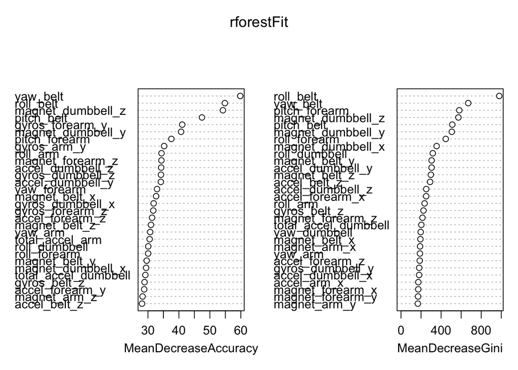

```r
# list out the variable importance
varImpPlot(rforestFit)
```

#Cross-Validation With Random Forest Model

```r
result=predict(rforestFit, wleTestSS)
cm<-confusionMatrix(wleTestSS$classe, result)
```

## Expected Out-Of-Sample Error and Estimated Sample Error

The expected out-of-sample error is 0.005301794, as well as the estimated sample error is 0.005301794.

```r
#Expected Out-Of-Sample Error
expOutOfSampleError<-1-cm$overall['Accuracy']
names(expOutOfSampleError)<-"Expected Out-Of-Sample Error"
expOutOfSampleError
```

```
## Expected Out-Of-Sample Error
##                  0.005301794
```

```r
#Estimated Sample Error
estSampleError<-1-(sum(result==wleTestSS$classe)/length(result))
estSampleError
```

```
## [1] 0.005301794
```

## Choosing the Final Model for the Prediction

Considering the high accuracy and the small sample error by ignoring the speed factor, I have decided to use the Random Forest Model to perform the prediction on the testing set.

```r
testingPred<-predict(rforestFit, wleValidate)
testingPred
```

```
##  1  2  3  4  5  6  7  8  9 10 11 12 13 14 15 16 17 18 19 20
##  B  A  B  A  A  E  D  B  A  A  B  C  B  A  E  E  A  B  B  B
## Levels: A B C D E
```

## Generate Prediction Output

```r
## Seed is set to 1221 to produce this results.
answer<-as.character(testingPred)
pml_write_files = function(x){
  n = length(x)
  for(i in 1:n){
    filename = paste0("problem_id_",i,".txt")
    write.table(x[i],file=filename,quote=FALSE,row.names=FALSE,col.names=FALSE)
  }
}
pml_write_files(answer)
```

## Conclusion

I have been convinced that using this Random Forest Model with the high accuracy and small error rate can be used to predict the manner executed in weight lifting exercises.